# Git, GitHub, and RStudio

January 30, 2024 @ 01:09 AM

## Why GitHub?

[figure not shown]

[artwork by @allison_horst](https://allisonhorst.com/allison-horst)

[figure not shown]

GitHub is a code hosting platform for collaboration and version control. It lets you and others work together on projects—from anywhere. GitHub interfaces with RStudio projects.

## Push-Pull Workflow

[figure not shown]

## Remember!

If you are a student, you can upgrade your free account to [Pro](https://docs.github.com/en/get-started/learning-about-github/githubs-products#github-pro) by [applying for student benefits](https://education.github.com/discount_requests/student_application), which includes private repos.

[figure not shown]

## Let’s Get Started!

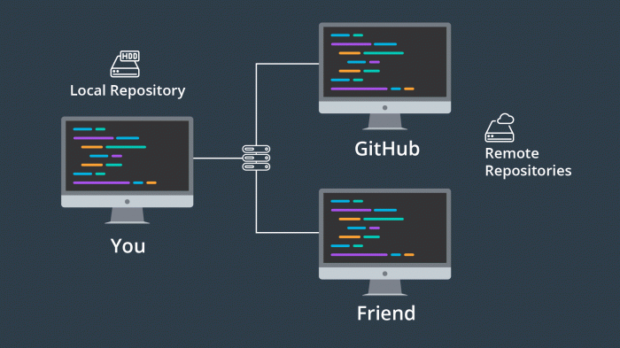

Log into your GitHub account at https://github.com

Log into the RStudio/Posix server at https://mathr.appstate.edu

## Commit Name and Email (Method 1)

In the past, this part needed to be done in a terminal in RStudio. You may refer to [Chapter 7](https://happygitwithr.com/hello-git.html) of *Happy Git and GitHub for the useR* or GitHub [Help](https://help.github.com/).

In RStudio, choose `Tools > Terminal > New Terminal`

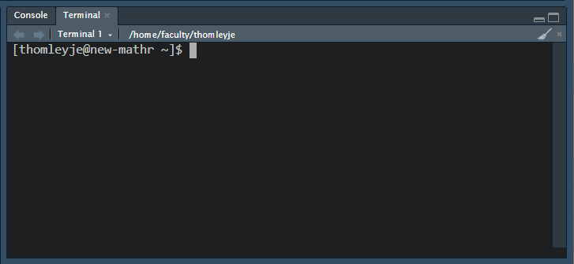

We will use the terminal for some processes, such as confirming our settings, but we will use Method 2 to set your commit name and email address.

In the **Terminal**, we would type the following lines at the prompt one at a time and hit `[Enter]` after each.

```r
git config --global user.email "who@where"
git config --global user.name "commitname"
```

These set an **[email](https://help.github.com/articles/setting-your-commit-email-address-in-git/)** and **[name](https://help.github.com/articles/setting-your-username-in-git/)** linked with any commit you make in Git. They do not have to be the same as your primary GitHub email and username. You can change them later.

To confirm, we can type the following. Try this one!

```r
git config --global --list
```

## Commit Name and Email (Method 2)

As happens with so many popular and widely used processes in R and RStudio, there is a package to help us interact with Git and GitHub during setup, which was created by Hadley Wickham and collaborators. The [usethis](https://usethis.r-lib.org/) package has been installed for us on the ASU RStudio server. [See the example script on AsULearn!]

In the RStudio **Console** pane (or using the **Source** pane), enter:

```r
library(usethis)
use_git_config(user.name = "commitname", user.email = "who@where")
```

Add a name and email for yourself. You still need to enter the code below in a **Terminal** window to check your configuration.

```r
git config --global --list
```

## Cache Those Credentials

Would you prefer not to repeatedly type in your username and personal access token (PAT)? Me too!

In the Terminal, type the following code at the prompt and hit `[Enter]`. The timeout value is 10 million (1 then seven 0’s).

```r
git config --global credential.helper 'cache --timeout=10000000'
```

This will store your password for ten million seconds, which is about 16 weeks, enough for a semester. Once it runs out, or if you change your password, just run it again.

The `global` option means the cache should apply to all of your Git projects. You can check with `git config --global --list` as you did with your commit name and email.

## Personal Access Token

Enter code below in RStudio’s Console pane (or use the Source pane) to go to GitHub’s personal access token page. **You must store the token that you’ll create, you will not be able see it again once you leave the page.** Treat it like a password!

```r
library(usethis)
create_github_token()
```

You can add/change a PAT using this function from the gitcreds package. It’s a good idea to change your PAT periodically.

```r
library(gitcreds)
gitcreds_set()
```

[Dr. Arnholt’s video about Personal Access Tokens](https://drive.google.com/file/d/1G9G8IeYu9QetYB1nxMmAFLgRtw5YC-c8/view) — go to 3:00

## Coming Out of Your Shell

Appendix A of *[Happy Git and GitHub for the useR](http://happygitwithr.com/)* discusses how to use shell commands to clone, commit, push, etc. These tools are also covered in a [DataCamp course](https://learn.datacamp.com/courses/introduction-to-git).

In this course we will use the point and click Git interface found in Environment pane of RStudio (discussed in [Chapter 12](https://happygitwithr.com/rstudio-git-github.html)).

Review Chapters [15](https://happygitwithr.com/new-github-first.html) and [16](https://happygitwithr.com/existing-github-first.html) for examples of how to create a new project or copy an existing project into a new version-controlled project using GitHub.

You may want to create a subdirectory in your **Home** directory in RStudio for all your version controlled projects. For example, my directory **git_repositories**.

There is a nice discussion about working with R projects **[here](https://support.rstudio.com/hc/en-us/articles/200526207-Using-Projects)**.

## Let’s Make a Repository

From your GitHub repository page (see image on next slide) …

- click on the green “New” button
- create a new repository named **STT2860ClassMaterial**
- add a description like “STT 2860 notes and worksheets”
- choose “Public” or “Private” (if you have private access)
- choose “Add a README file”
- click the green “Create repository” button (*drum roll …*)

Adding a license is optional. If you want one, the [MIT license](https://opensource.org/licenses/MIT) is a good general purpose license.

Why a license? Public repositories can be copied by anyone else on GitHub, so you want to establish the parameters of use.

[figure not shown]

## Clone it !

In your **STT2860ClassMaterial** GitHub repo (pic on next slide) …

- choose the green “Code” button in your repo
  - select “Use HTTPS”
  - copy the HTTPS clone URL to your clipboard

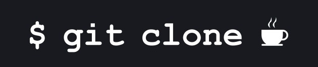

Note: You can use SSH authentication if you want to. There’s a GitHub page **[here](https://help.github.com/articles/which-remote-url-should-i-use/)** that discusses the differences. I usually use HTTPS, since most of my content is open/sharable.

You are going to copy the URL to connect GitHub to a project in RStudio with the same name.

[figure not shown]

## Let’s Make a Project

In RStudio…

- choose **File > New Project > Version Control > Git**
- paste in the repository URL from the the clipboard where it says “Repository URL:”
- the project directory name should be filled in automatically if you use CTRL-V to paste, otherwise you will have to type it in under “Project directory name:”
- choose your version control subdirectory, if you made one, where it says “Create project as a subdirectory of:”
- click **Create Project**!

## Create, Commit, Push, Pull

I’m just going to talk here for now, so follow along …

Changes made in RStudio are *pushed* to GitHub. Changes made in GitHub are *pulled* to RStudio. You must *commit* your changes (make them official) before you push or pull.

## Commit-iquette

These suggestions for GitHub commit etiquette were adapted from [How to use GitHub like a proper human being](https://medium.com/@takouhai/how-to-use-github-like-a-proper-human-being-1a9c895c4e13).

- Keep commits atomic. A commit should revolve around ONE change. If you have to add “and” you’ve committed too much.
- Capitalize the first word your commit message. Sentence case is more professional and easier to read.
- Keep your commit message under 50 characters.
- Do not end your commit message with a period.
- Use an imperative commit message, like a command.
- Use consistent language in your commit messages.

## Forking Repos

Let’s go to FiveThirtyEight’s [Data repo](https://github.com/fivethirtyeight/data) …

[figure not shown]

## Creating Web Pages

Go to Dr. Thomley’s [Basic Web Page Template repository](https://github.com/stt2860/basicwebpagetemplate) …

[figure not shown]

Go to Dr. Thomley’s [Web Page repository](https://github.com/jillthomley/jillthomley.github.io) …

[figure not shown]